# Repro_alloc_1

R.Ward

3/10/2019

The goal of this preliminary analysis is to look at the allocation to reproduction among BCI’s most common species, and compare allocation fractions between PFTs.

We’re interested in:

repro_output / leaf_litter_output

seed_ouput / repro_output

Our PFTs are: drought tolerant and intolerant (dt/di) and early and late successional(es/ls).  
- Adam HB has filtered BCI species list for those with greater than 50 reproductive individuals, giving us a list of 26 species.  
- Joe Wright has extracted the summed reproductive output for these species from two sites, with 62 and 60 traps respectively.

```r
library(tidyverse)
library(readr)
library(skimr)
```

1. Importing species list:

```r
#this file contains the spp list and pfts for the 26 spp identified with more than 50 repro individuals
species_list_26 <- read_csv("species_list_for_repro_alloc_26_mostabund_sp.csv", col_types = cols(
  sp = col_character(),
  Latin = col_character(),
  dmax = col_double(),
  wsg = col_double(),
  e_vs_l = col_factor(),
  dpft = col_factor(),
  repro_abund_2010 = col_double(),
  pft = col_factor()
))
head(species_list_26)
```

```
## # A tibble: 6 x 8
##   sp     Latin              dmax   wsg e_vs_l dpft  repro_abund_2010 pft
##   <chr>  <chr>             <dbl> <dbl> <fct>  <fct>            <dbl> <fct>
## 1 tri2tu Trichilia tuberc…  991. 0.628 late   dt                 402 latedt
## 2 quaras Quararibea aster… 2071. 0.454 early  dt                 374 early…
## 3 alsebl Alseis blackiana   982. 0.536 late   di                 371 latedi
## 4 tab2ar Tabernaemontana …  952. 0.525 late   dt                 173 latedt
## 5 jac1co Jacaranda copaia  1210. 0.351 early  dt                 171 early…
## 6 pri2co Prioria copaifera 1444. 0.414 early  dt                 169 early…
```

2. Importing BCI trait data:
- Reproductive trait data is from BCITRAITS
- Units are in g

```r
bci_repro_traits <- read_csv("BCITRAITS_20101220 (1).csv") %>%
                    mutate(sp = tolower(`SP$`)) %>%
                    select(sp, FRUIT_DRY, N_SEEDFULL, SEED_DRY, DSPR_DRY)
#view(BCITRAITS_20101220_1_)

head(bci_repro_traits)
```

```
## # A tibble: 6 x 5
##   sp     FRUIT_DRY N_SEEDFULL SEED_DRY DSPR_DRY
##   <chr>      <dbl>      <dbl>    <dbl>    <dbl>
## 1 abutra     0.386          1   0.0352    0.177
## 2 acacha    NA             NA  NA        NA
## 3 acacme    NA             NA  NA        NA
## 4 acaldi    NA             NA  NA        NA
## 5 acalma    NA             NA  NA        NA
## 6 ade1tr    NA             NA  NA        NA
```

3. Importing basal area and reproductive basal area data for the 50 ha plot:
- provided by Adam HB, units in m2, for year 2010

```r
b_area <- read_csv("basal_area_2010.csv") %>%
              select(sp, ba)
rb_area <- read_csv("repro_basal_area_df.csv") %>%
           select(sp, r_ba)
```

4. Joining the sp. list, bci traits, and basal area data:
- checking missing values for our list of 26 species

```r
sp_traits <- species_list_26 %>%
                    left_join(bci_repro_traits, by = "sp") %>%
                    left_join(b_area, by = "sp") %>%
                    left_join(rb_area, by = "sp")

head(sp_traits)
```

```
## # A tibble: 6 x 14
##   sp    Latin  dmax   wsg e_vs_l dpft  repro_abund_2010 pft   FRUIT_DRY
##   <chr> <chr> <dbl> <dbl> <fct>  <fct>            <dbl> <fct>     <dbl>
## 1 tri2… Tric…  991. 0.628 late   dt                 402 late…    0.521
## 2 quar… Quar… 2071. 0.454 early  dt                 374 earl…    1.26
## 3 alse… Alse…  982. 0.536 late   di                 371 late…    0.0126
## 4 tab2… Tabe…  952. 0.525 late   dt                 173 late…   21.1
## 5 jac1… Jaca… 1210. 0.351 early  dt                 171 earl…    7.36
## 6 pri2… Prio… 1444. 0.414 early  dt                 169 earl…   36.0
## # … with 5 more variables: N_SEEDFULL <dbl>, SEED_DRY <dbl>,
## #   DSPR_DRY <dbl>, ba <dbl>, r_ba <dbl>
```

```r
skim(sp_traits)
```

```
## Skim summary statistics
##  n obs: 26
##  n variables: 14
##
## ── Variable type:character ─────────────────────────────────────────────────────
##  variable missing complete  n min max empty n_unique
##     Latin       0       26 26  13  23     0       26
##        sp       0       26 26   6   6     0       26
##
## ── Variable type:factor ────────────────────────────────────────────────────────
##  variable missing complete  n n_unique                       top_counts
##      dpft       0       26 26        2             dt: 21, di: 5, NA: 0
##    e_vs_l       0       26 26        2          lat: 13, ear: 13, NA: 0
##       pft       0       26 26        4 ear: 11, lat: 10, lat: 3, ear: 2
##  ordered
##    FALSE
##    FALSE
##    FALSE
##
## ── Variable type:numeric ───────────────────────────────────────────────────────
##          variable missing complete  n    mean     sd        p0    p25
##                ba       0       26 26   34.93  26.77  11.74     18.29
##              dmax       0       26 26 1094.04 509.36 476.17    782.25
##          DSPR_DRY       4       22 26    2.12   5.19   9.8e-05   0.07
##         FRUIT_DRY       4       22 26    9.61  23.33   0.013     0.53
##        N_SEEDFULL       4       22 26   20.67  52.51   1         1
##              r_ba       0       26 26   10.99  10.07   0.71      5.52
##  repro_abund_2010       0       26 26  130.42  99.2   50        73
##          SEED_DRY       5       21 26    1.71   5.06   4.9e-05   0.03
##               wsg       0       26 26    0.49   0.13   0.28      0.39
##      p50     p75    p100     hist
##   23.31    34.56  120.81 ▇▃▁▁▂▁▁▁
##  960.17  1345.21 2820.67 ▅▇▂▃▁▁▁▁
##    0.21     0.63   23.45 ▇▁▁▁▁▁▁▁
##    1.4      6.44  107.04 ▇▁▁▁▁▁▁▁
##    1.3      4.16  195.38 ▇▁▁▁▁▁▁▁
##    8.18    14.36   50.38 ▇▆▃▂▁▁▁▁
##   92.5    139     402    ▇▃▂▁▁▁▁▂
##    0.099    0.29   22.87 ▇▁▁▁▁▁▁▁
##    0.49     0.58    0.79 ▅▆▇▇▆▅▂▂
```

```r
#From the skim, note there are 5 sp for which BCI traits is missing trait values


missing_values <- sp_traits %>%
                  filter(is.na(DSPR_DRY) | is.na(FRUIT_DRY) | is.na(N_SEEDFULL) | is.na(SEED_DRY))

missing_values
```

```
## # A tibble: 5 x 14
##   sp    Latin  dmax   wsg e_vs_l dpft  repro_abund_2010 pft   FRUIT_DRY
##   <chr> <chr> <dbl> <dbl> <fct>  <fct>            <dbl> <fct>     <dbl>
## 1 cecr… Cecr…  696. 0.318 early  di                 103 earl…     NA
## 2 zant… Zant…  846. 0.609 late   dt                  94 late…     NA
## 3 ocot… Ocot… 1372. 0.526 late   dt                  79 late…      8.92
## 4 guar… Guar…  576. 0.568 late   di                  73 late…     NA
## 5 hura… Hura… 2821. 0.367 early  dt                  73 earl…     NA
## # … with 5 more variables: N_SEEDFULL <dbl>, SEED_DRY <dbl>,
## #   DSPR_DRY <dbl>, ba <dbl>, r_ba <dbl>
```

5. Importing 50-ha plot data
- This file sums 62 x 0.5m2 traps in the 50 ha plot for which masses were recorded from 25 June 2013 through 29 January 2019
- The types are leaves, flowers, immature fruit and mature fruit (including seeds, entire fruit, capsules, and fruit damaged by vertebrates or insects)

```r
mass_data_50haplot <- read_csv("Hanbury_Brown_50ha_20190221.csv", col_types = cols(sp = col_character(),
                                                                                   type = col_factor(),
                                                                                   mass = col_double(),
                                                                                   Freq = col_double())
                                                                                      )
skim(mass_data_50haplot)
```

```
## Skim summary statistics
##  n obs: 99
##  n variables: 4
##
## ── Variable type:character ─────────────────────────────────────────────────────
##  variable missing complete  n min max empty n_unique
##        sp       0       99 99   6   6     0       26
##
## ── Variable type:factor ────────────────────────────────────────────────────────
##  variable missing complete  n n_unique                         top_counts
##      type       0       99 99        4 lea: 26, flo: 25, mat: 25, imm: 23
##  ordered
##    FALSE
##
## ── Variable type:numeric ───────────────────────────────────────────────────────
##  variable missing complete  n   mean      sd p0   p25   p50   p75   p100
##      Freq       0       99 99  17.91   16.56  1  5     12    26     64
##      mass       0       99 99 729.06 1280.25  0 23.35  99.8 873.4 7059.8
##      hist
##  ▇▂▃▂▁▁▁▁
##  ▇▁▁▁▁▁▁▁
```

```r
head(mass_data_50haplot)
```

```
## # A tibble: 6 x 4
##   sp     type             mass  Freq
##   <chr>  <fct>           <dbl> <dbl>
## 1 alchco flower            0       2
## 2 alchco leaf             39.6    11
## 3 alchco mature fruit      0.6    18
## 4 alsebl flower           76.4    24
## 5 alsebl immature fruit    3      15
## 6 alsebl leaf           4484.     53
```

6. Scaling: Reproductive mass:
- Our mass value is a sum of reproductive output from 25 June 2013 through 29 January 2019 (67 months)
- Reproductive output per year = $R_{mass} / 67_{mo} * 12_{mo} / year = R_{mass} / year$
- Mass per m2 for 62 0.5m2 traps = $R_{mass}/ 31 m^2$
- Reproductive mass per m2 scaled to the 50 ha plot by sp reproductive basal area = $R_{mass} / m^2 * 500,000 m^2 * 1/ BA_{R} (m^2)$

Leaf litter mass:  
- Leaf litter output per year per year = $L_{mass} / 67_{mo} * 12_{mo} / year = L_{mass} / year$  
- Mass per m2 for 62 0.5m2 traps = $L_{mass}/ 31 m^2$  
- Leaf litter mass per m2 scaled to the 50 ha plot by sp total basal area = $L_{mass} / m^2 * 500,000 m^2 * 1/ BA m^2)$

```r
repro_total_df <- mass_data_50haplot %>%
                  left_join(sp_traits, by = "sp") %>%
                  filter(type != "leaf") %>%
                  group_by(sp)%>%
                  mutate(repro_mass_total = sum(mass)) %>%
                  mutate(repro_mass_per_yr = repro_mass_total * 12 / 67) %>%
                  mutate(repro_mass_per_yr_m2 = repro_mass_per_yr / 31) %>%
                  mutate(repro_mass_per_yr_indv = repro_mass_per_yr / repro_abund_2010) %>%
                  mutate(repro_output_50_ha = (repro_mass_per_yr_m2 * 500000 / r_ba)) %>%
                  filter(type == "mature fruit") %>%
                  mutate(mature_frt_mass = sum(mass)) %>%
                  select(sp, mature_frt_mass, repro_mass_total, repro_mass_per_yr_indv, repro_mass_per_yr, repro_mass_per_yr_m2, repro_output_50_ha) %>%
                  distinct(sp, .keep_all = T)

repro_total_df
```

```
## # A tibble: 25 x 7
## # Groups:   sp [25]
##    sp    mature_frt_mass repro_mass_total repro_mass_per_… repro_mass_per_…
##    <chr>           <dbl>            <dbl>            <dbl>            <dbl>
##  1 alch…             0.6              0.6          0.00141            0.107
##  2 alse…           715.             795.           0.384            142.
##  3 apei…            33.2             45            0.0739             8.06
##  4 beil…           294.             354.           0.487             63.3
##  5 bros…            59.8             97.9          0.351             17.5
##  6 cecr…            18.7           1065.           1.85             191.
##  7 cord…           150.             208.           0.316             37.3
##  8 guap…            35.5            637            2.07             114.
##  9 guar…            47.8             54.5          0.134              9.76
## 10 guat…            10.9             68.1          0.210             12.2
## # … with 15 more rows, and 2 more variables: repro_mass_per_yr_m2 <dbl>,
## #   repro_output_50_ha <dbl>
```

```r
leaf_total_df <- mass_data_50haplot %>%
                 left_join(sp_traits, by = "sp") %>%
                 filter(type == "leaf") %>%
                 group_by(sp) %>%
                 mutate(leaf_mass_per_yr = mass * 12 / 67) %>%
                 mutate(leaf_mass_per_yr_m2 = leaf_mass_per_yr / 31) %>%
                 mutate(leaf_output_50_ha = (leaf_mass_per_yr_m2 * 500000 / ba)) %>%
                 select(sp, leaf_mass_per_yr, leaf_mass_per_yr_m2, leaf_output_50_ha) %>%
                 distinct(sp, .keep_all = T)

leaf_total_df
```

```
## # A tibble: 26 x 4
## # Groups:   sp [26]
##    sp     leaf_mass_per_yr leaf_mass_per_yr_m2 leaf_output_50_ha
##    <chr>             <dbl>               <dbl>             <dbl>
##  1 alchco             7.09               0.229             9743.
##  2 alsebl           803.                25.9             163129.
##  3 apeime           159.                 5.14             74951.
##  4 beilpe           227.                 7.33            118542.
##  5 brosal           249.                 8.04            120703.
##  6 cecrin           609.                19.6             457337.
##  7 cordbi            86.5                2.79             78482.
##  8 guapst           694.                22.4             851006.
##  9 guargu           153.                 4.95            155253.
## 10 guatdu            35.9                1.16             38194.
## # … with 16 more rows
```

7. Joining all sp specific trait data:

```r
Repro_trait_data <- sp_traits %>%
                    left_join(repro_total_df, by = "sp") %>%
                    left_join(leaf_total_df, by = "sp") %>%
                    mutate(frac_repro_output = repro_output_50_ha / leaf_output_50_ha)

head(Repro_trait_data)
```

```
## # A tibble: 6 x 24
##   sp    Latin  dmax   wsg e_vs_l dpft  repro_abund_2010 pft   FRUIT_DRY
##   <chr> <chr> <dbl> <dbl> <fct>  <fct>            <dbl> <fct>     <dbl>
## 1 tri2… Tric…  991. 0.628 late   dt                 402 late…    0.521
## 2 quar… Quar… 2071. 0.454 early  dt                 374 earl…    1.26
## 3 alse… Alse…  982. 0.536 late   di                 371 late…    0.0126
## 4 tab2… Tabe…  952. 0.525 late   dt                 173 late…   21.1
## 5 jac1… Jaca… 1210. 0.351 early  dt                 171 earl…    7.36
## 6 pri2… Prio… 1444. 0.414 early  dt                 169 earl…   36.0
## # … with 15 more variables: N_SEEDFULL <dbl>, SEED_DRY <dbl>,
## #   DSPR_DRY <dbl>, ba <dbl>, r_ba <dbl>, mature_frt_mass <dbl>,
## #   repro_mass_total <dbl>, repro_mass_per_yr_indv <dbl>,
## #   repro_mass_per_yr <dbl>, repro_mass_per_yr_m2 <dbl>,
## #   repro_output_50_ha <dbl>, leaf_mass_per_yr <dbl>,
## #   leaf_mass_per_yr_m2 <dbl>, leaf_output_50_ha <dbl>,
## #   frac_repro_output <dbl>
```

```r
skim(Repro_trait_data)
```

```
## Skim summary statistics
##  n obs: 26
##  n variables: 24
##
## ── Variable type:character ─────────────────────────────────────────────────────
##  variable missing complete  n min max empty n_unique
##     Latin       0       26 26  13  23     0       26
##        sp       0       26 26   6   6     0       26
##
## ── Variable type:factor ────────────────────────────────────────────────────────
##  variable missing complete  n n_unique                       top_counts
##      dpft       0       26 26        2             dt: 21, di: 5, NA: 0
##    e_vs_l       0       26 26        2          lat: 13, ear: 13, NA: 0
##       pft       0       26 26        4 ear: 11, lat: 10, lat: 3, ear: 2
##  ordered
##    FALSE
##    FALSE
##    FALSE
##
## ── Variable type:numeric ───────────────────────────────────────────────────────
##                variable missing complete  n      mean         sd
##                      ba       0       26 26     34.93      26.77
##                    dmax       0       26 26   1094.04     509.36
##                DSPR_DRY       4       22 26      2.12       5.19
##       frac_repro_output       1       25 26      4.27      17.4
##               FRUIT_DRY       4       22 26      9.61      23.33
##        leaf_mass_per_yr       0       26 26    373.29     320.78
##     leaf_mass_per_yr_m2       0       26 26     12.04      10.35
##       leaf_output_50_ha       0       26 26 185451.69  175405.23
##         mature_frt_mass       1       25 26    326.23     559.57
##              N_SEEDFULL       4       22 26     20.67      52.51
##                    r_ba       0       26 26     10.99      10.07
##        repro_abund_2010       0       26 26    130.42      99.2
##       repro_mass_per_yr       1       25 26    128.87     202.37
##  repro_mass_per_yr_indv       1       25 26      0.85       0.94
##    repro_mass_per_yr_m2       1       25 26      4.16       6.53
##        repro_mass_total       1       25 26    719.51    1129.89
##      repro_output_50_ha       1       25 26 733420.08 2934569.42
##                SEED_DRY       5       21 26      1.71       5.06
##                     wsg       0       26 26      0.49       0.13
##          p0      p25        p50       p75         p100     hist
##    11.74       18.29     23.31      34.56    120.81    ▇▃▁▁▂▁▁▁
##   476.17      782.25    960.17    1345.21   2820.67    ▅▇▂▃▁▁▁▁
##     9.8e-05     0.07      0.21       0.63     23.45    ▇▁▁▁▁▁▁▁
##     0.029       0.19      0.56       0.93     87.68    ▇▁▁▁▁▁▁▁
##     0.013       0.53      1.4        6.44    107.04    ▇▁▁▁▁▁▁▁
##     7.09      147.69    251.43     576.64   1264.44    ▇▅▃▃▁▁▁▁
##     0.23        4.76      8.11      18.6      40.79    ▇▅▃▃▁▁▁▁
##  7636.57    90132.66 138978.87  213751.02 851005.77    ▆▇▁▁▁▁▁▁
##     0          24.2      59.8      347.1    2326.6     ▇▂▁▁▁▁▁▁
##     1           1         1.3        4.16    195.38    ▇▁▁▁▁▁▁▁
##     0.71        5.52      8.18      14.36     50.38    ▇▆▃▂▁▁▁▁
##    50          73        92.5      139       402       ▇▃▂▁▁▁▁▂
##     0.11       17.25     61.67     121.79    843.83    ▇▃▁▁▁▁▁▁
##     0.0014      0.18      0.38       1.14      3.17    ▇▁▂▁▁▁▁▁
##     0.0035      0.56      1.99       3.93     27.22    ▇▃▁▁▁▁▁▁
##     0.6        96.3     344.3      680      4711.4     ▇▃▁▁▁▁▁▁
##   611.97    25937.13 108162.71   3e+05         1.5e+07 ▇▁▁▁▁▁▁▁
##     4.9e-05     0.03      0.099      0.29     22.87    ▇▁▁▁▁▁▁▁
##     0.28        0.39      0.49       0.58      0.79    ▅▆▇▇▆▅▂▂
```

```r
outliers<- Repro_trait_data %>%
   filter(frac_repro_output >= 1.0) %>%
   select(sp, repro_mass_per_yr_m2, ba, r_ba, repro_output_50_ha, leaf_output_50_ha, frac_repro_output)

outliers
```

```
## # A tibble: 6 x 7
##   sp    repro_mass_per_…    ba   r_ba repro_output_50… leaf_output_50_…
##   <chr>            <dbl> <dbl>  <dbl>            <dbl>            <dbl>
## 1 tri2…            3.93   76.8  5.62           349800.          114454.
## 2 quar…           27.2   121.   0.919        14801998.          168811.
## 3 jac1…           17.5    44.8 20.8            420714.          211431.
## 4 viro…            3.33   25.1  5.49           303298.          261674.
## 5 viro…            0.627  20.0  0.706          444091.          141032.
## 6 gust…            3.90   20.9  9.21           211998.          136925.
## # … with 1 more variable: frac_repro_output <dbl>
```

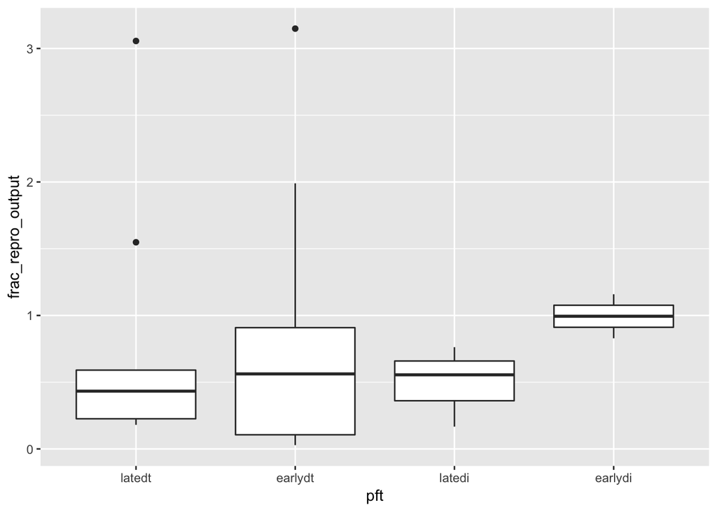

```r
#the sp quaras seems to have an error in basal area or reproductive basal area measure
#basal area is reported as 120.8 m2, reproductive basal area is reported as 0.91 m2
#Quaras repro_output per year per m2 = 27.22g, it seems unlikely repro basal area is only .9
#the resulting fraction of repro_output / leaf_output = 87
#removed quaras from below boxplots

Repro_trait_data %>%
        group_by(pft) %>%
        filter(sp != "quaras") %>%
        ggplot(aes(pft, frac_repro_output)) + geom_boxplot()
```

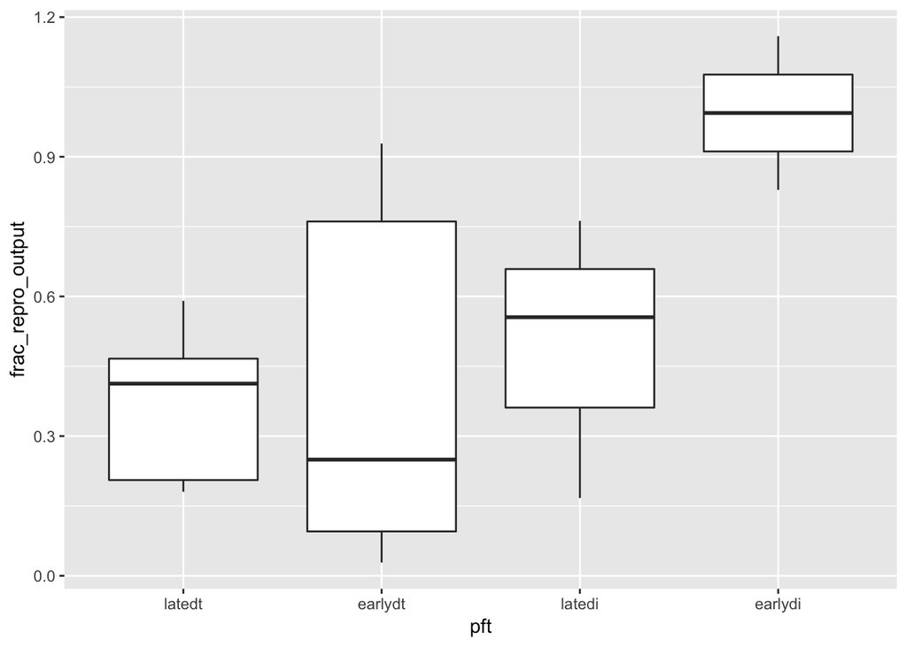

```r
#arbitrarily expluding potential outliers, where frac_repro_output was greater than 1.5
#even exluding these, the average frac of repro_output/leaf_litter_output >> 0.1

Repro_trait_data %>%
        group_by(pft) %>%
        filter(frac_repro_output < 1.5) %>%
        ggplot(aes(pft, frac_repro_output)) + geom_boxplot()
```

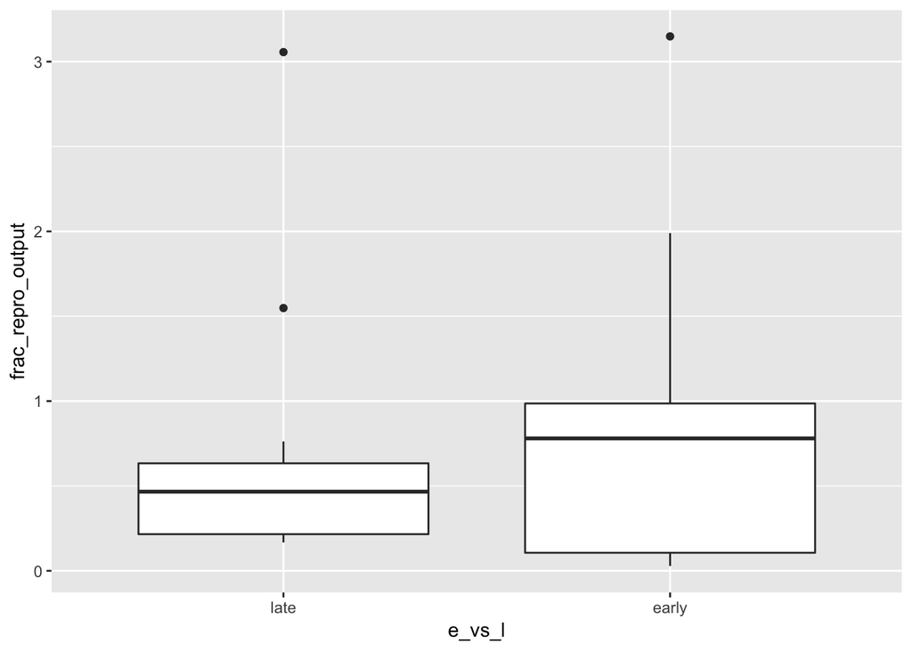

```r
Repro_trait_data %>%
        group_by(e_vs_l) %>%
        filter(sp != "quaras") %>%
        ggplot(aes(e_vs_l, frac_repro_output)) + geom_boxplot()
```

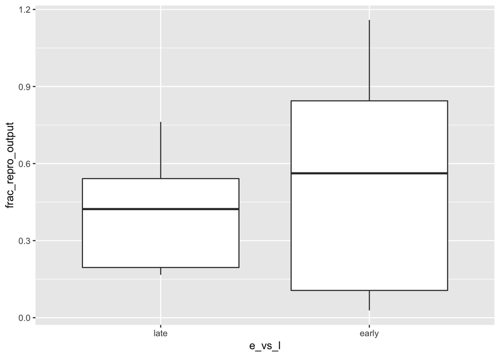

```r
Repro_trait_data %>%
        group_by(e_vs_l) %>%
        filter(frac_repro_output < 1.5) %>%
        ggplot(aes(e_vs_l, frac_repro_output)) + geom_boxplot()
```

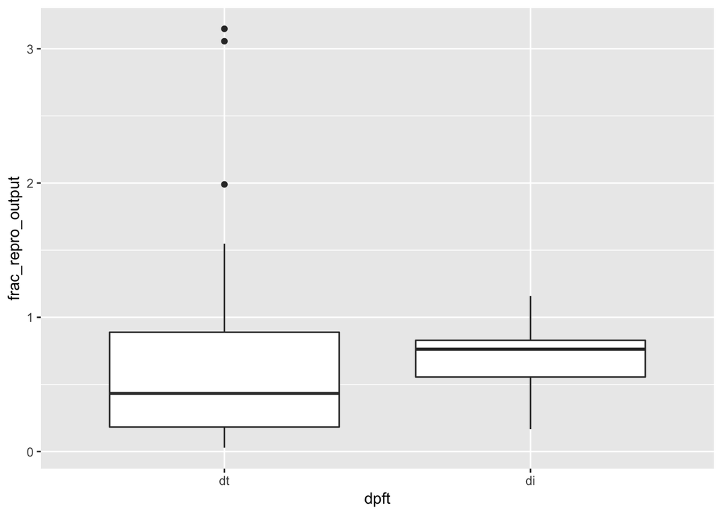

```r
Repro_trait_data %>%
        group_by(dpft) %>%
        filter(sp != "quaras") %>%
        ggplot(aes(dpft, frac_repro_output)) + geom_boxplot()
```

8. Calculating expected seed mass, and fraction of reproductive output that is seed:
- Mass in the mature fruit category is treated as fruit (although we are aware that this category includes seeds, entire fruit, capsules, and fruit damaged by vertebrates or insects)
- Expected seed mass is calculatec from mature fruit mass using BCI trait measures for average weight of dried fruit, average number of seeds per fruit, and average weight of dried seeds
- Expected seed mass = Mature_frt_mass / fruit_dry_mass * number_seeds * seed_weight
- Units for the numerator and denominator of this fraction are in g, both are summed over 67 months for 31 m2

```r
repro_seeds_df <- Repro_trait_data %>%
                  mutate(expd_seed_mass = ((mature_frt_mass/ FRUIT_DRY) * N_SEEDFULL * SEED_DRY)) %>%
                  mutate(fract_seed_of_repro = expd_seed_mass / repro_mass_total)

head(repro_seeds_df)
```

```
## # A tibble: 6 x 26
##   sp    Latin  dmax   wsg e_vs_l dpft  repro_abund_2010 pft   FRUIT_DRY
##   <chr> <chr> <dbl> <dbl> <fct>  <fct>            <dbl> <fct>     <dbl>
## 1 tri2… Tric…  991. 0.628 late   dt                 402 late…    0.521
## 2 quar… Quar… 2071. 0.454 early  dt                 374 earl…    1.26
## 3 alse… Alse…  982. 0.536 late   di                 371 late…    0.0126
## 4 tab2… Tabe…  952. 0.525 late   dt                 173 late…   21.1
## 5 jac1… Jaca… 1210. 0.351 early  dt                 171 earl…    7.36
## 6 pri2… Prio… 1444. 0.414 early  dt                 169 earl…   36.0
## # … with 17 more variables: N_SEEDFULL <dbl>, SEED_DRY <dbl>,
## #   DSPR_DRY <dbl>, ba <dbl>, r_ba <dbl>, mature_frt_mass <dbl>,
## #   repro_mass_total <dbl>, repro_mass_per_yr_indv <dbl>,
## #   repro_mass_per_yr <dbl>, repro_mass_per_yr_m2 <dbl>,
## #   repro_output_50_ha <dbl>, leaf_mass_per_yr <dbl>,
## #   leaf_mass_per_yr_m2 <dbl>, leaf_output_50_ha <dbl>,
## #   frac_repro_output <dbl>, expd_seed_mass <dbl>,
## #   fract_seed_of_repro <dbl>
```

```r
skim(repro_seeds_df)
```

```
## Skim summary statistics
##  n obs: 26
##  n variables: 26
##
## ── Variable type:character ─────────────────────────────────────────────────────
##  variable missing complete  n min max empty n_unique
##     Latin       0       26 26  13  23     0       26
##        sp       0       26 26   6   6     0       26
##
## ── Variable type:factor ────────────────────────────────────────────────────────
##  variable missing complete  n n_unique                       top_counts
##      dpft       0       26 26        2             dt: 21, di: 5, NA: 0
##    e_vs_l       0       26 26        2          lat: 13, ear: 13, NA: 0
##       pft       0       26 26        4 ear: 11, lat: 10, lat: 3, ear: 2
##  ordered
##    FALSE
##    FALSE
##    FALSE
##
## ── Variable type:numeric ───────────────────────────────────────────────────────
##                variable missing complete  n      mean         sd
##                      ba       0       26 26     34.93      26.77
##                    dmax       0       26 26   1094.04     509.36
##                DSPR_DRY       4       22 26      2.12       5.19
##          expd_seed_mass       5       21 26     90.74     140.51
##       frac_repro_output       1       25 26      4.27      17.4
##     fract_seed_of_repro       5       21 26      0.16       0.15
##               FRUIT_DRY       4       22 26      9.61      23.33
##        leaf_mass_per_yr       0       26 26    373.29     320.78
##     leaf_mass_per_yr_m2       0       26 26     12.04      10.35
##       leaf_output_50_ha       0       26 26 185451.69  175405.23
##         mature_frt_mass       1       25 26    326.23     559.57
##              N_SEEDFULL       4       22 26     20.67      52.51
##                    r_ba       0       26 26     10.99      10.07
##        repro_abund_2010       0       26 26    130.42      99.2
##       repro_mass_per_yr       1       25 26    128.87     202.37
##  repro_mass_per_yr_indv       1       25 26      0.85       0.94
##    repro_mass_per_yr_m2       1       25 26      4.16       6.53
##        repro_mass_total       1       25 26    719.51    1129.89
##      repro_output_50_ha       1       25 26 733420.08 2934569.42
```

[output cut: 9 more lines]

```
##     0.013       0.53       1.4        6.44    107.04    ▇▁▁▁▁▁▁▁
##     7.09      147.69     251.43     576.64   1264.44    ▇▅▃▃▁▁▁▁
##     0.23        4.76       8.11      18.6      40.79    ▇▅▃▃▁▁▁▁
##  7636.57    90132.66  138978.87  213751.02 851005.77    ▆▇▁▁▁▁▁▁
##     0          24.2       59.8      347.1    2326.6     ▇▂▁▁▁▁▁▁
##     1           1          1.3        4.16    195.38    ▇▁▁▁▁▁▁▁
##     0.71        5.52       8.18      14.36     50.38    ▇▆▃▂▁▁▁▁
##    50          73         92.5      139       402       ▇▃▂▁▁▁▁▂
##     0.11       17.25      61.67     121.79    843.83    ▇▃▁▁▁▁▁▁
##     0.0014      0.18       0.38       1.14      3.17    ▇▁▂▁▁▁▁▁
##     0.0035      0.56       1.99       3.93     27.22    ▇▃▁▁▁▁▁▁
##     0.6        96.3      344.3      680      4711.4     ▇▃▁▁▁▁▁▁
##   611.97    25937.13  108162.71   3e+05         1.5e+07 ▇▁▁▁▁▁▁▁
##     4.9e-05     0.03       0.099      0.29     22.87    ▇▁▁▁▁▁▁▁
##     0.28        0.39       0.49       0.58      0.79    ▅▆▇▇▆▅▂▂
```

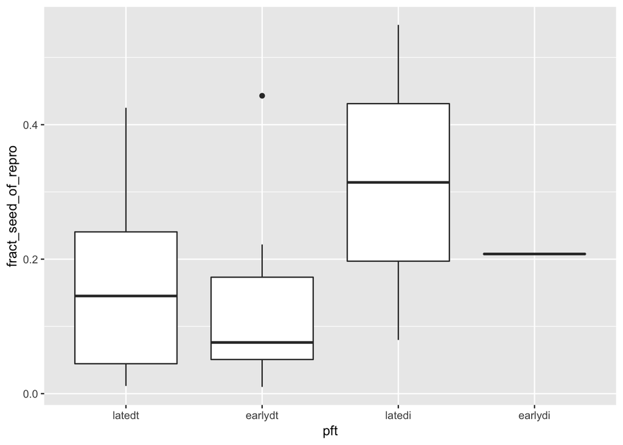

```r
#graphing pft
repro_seeds_df %>%
        group_by(pft) %>%
        ggplot(aes(pft, fract_seed_of_repro)) + geom_boxplot()
```

```r
#summarizing by pft
repro_seeds_df %>%
        group_by(pft) %>%
        summarize(per_pft_seed_frac_repro = mean(fract_seed_of_repro, na.rm = T),
                  se = sd(fract_seed_of_repro, na.rm = T)/length(fract_seed_of_repro))
```

```
## # A tibble: 4 x 3
##   pft     per_pft_seed_frac_repro      se
##   <fct>                     <dbl>   <dbl>
## 1 latedt                    0.162  0.0143
## 2 earlydt                   0.124  0.0120
## 3 latedi                    0.314  0.110
## 4 earlydi                   0.208 NA
```

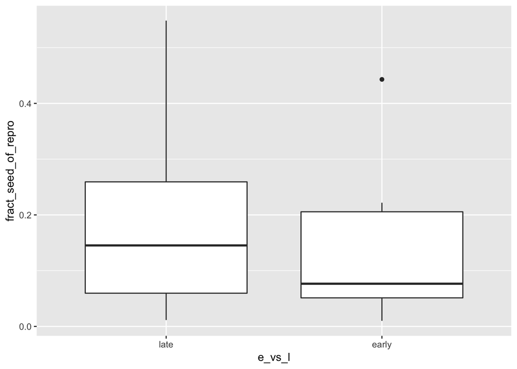

```r
#graphing e_vs_l
repro_seeds_df %>%
        group_by(e_vs_l) %>%
        ggplot(aes(e_vs_l, fract_seed_of_repro)) + geom_boxplot()
```

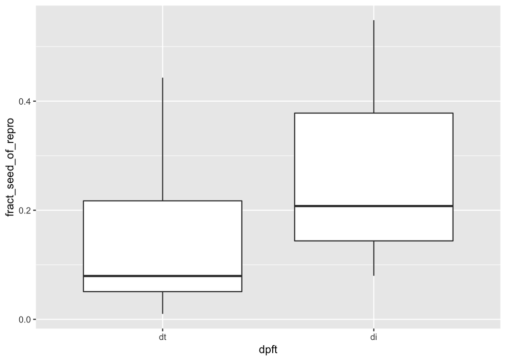

```r
#graphing dt vs di
repro_seeds_df %>%
        group_by(dpft) %>%
        ggplot(aes(dpft, fract_seed_of_repro)) + geom_boxplot()
```

Next steps:  
1. Find/estimate missing values for bci traits (perhaps from similar sp, if not availibe from J. Wright)  
2. Add additional sp. if possible (esp for underrepresended PFTs in this 26 sp sample)  
3. Correct biases:  
- losses to herbivory (ask J Wright for guidance here)  
- sp biased with respect to spatial sampling